# lm_fit for covid infection and temperature

Claire

12/17/2021

There are indications that the environmental temperature may be an important factor.

project aim: I perform a statistical analysis for understanding the effect of the environmental temperature on the exponential growth rate of the cases infected by COVID-19 for Belgium and Luxembourg regions.

## standard model for the evolution of the infected cases by viruses

$$dN/dt=L(N) \cdot F(N), \quad with \quad L(N) = \lambda \cdot N, F(N)=1-N^b$$
##where N(t) is the number of total infected cases,Nmax is the maximum possible number of infected cases. ## In short, from the perspective of the model, there are two parameters that affect the Covid infection rate, $\lambda$, and b. This project is to prove that the $\lambda$ is infected by the enviromental temperature.

statistic mode
$$\pmb{Y= \beta_0+\beta_1T+\epsilon \quad where \quad \epsilon \sim N(0,\sigma^2)}$$
# Where Y is set to be the log data of weekly new cases 𝑌=𝑐𝜆=log(∆𝑁) # T is set to be the weekly average temperature.

Hypothesis: $H_0：\beta_1 =0 ；H1:\beta _1 \neq0$

# Libraries

```r
library(tidyverse)
```

```r
library(ggplot2)
library(dplyr)
library(ggfortify)
library(lubridate)
```

# coivd data source and import data

```r
weekdata <- read.csv("https://opendata.ecdc.europa.eu/covid19/testing/csv/data.csv", na.strings = "", fileEncoding = "UTF-8-BOM")
```

```r
sum(weekdata$new_cases)
```

```
## [1] 86039417
```

```r
weekdata %>%
 group_by(region_name) %>%
 summarise(cases_sum = sum(new_cases), cases_max = max(new_cases)) %>%
 arrange(desc(cases_sum))
```

```
## # A tibble: 155 x 3
##    region_name   cases_sum cases_max
##    <chr>             <int>     <int>
##  1 France          8886063   1121911
##  2 Germany         7217474    403356
##  3 Italy           6188058    478107
##  4 Spain           5593589    630190
##  5 Poland          4105613    194006
##  6 Netherlands     3165470    157158
##  7 Czechia         2483794    128614
##  8 Portugal        2444968    148433
##  9 Belgium         2132407    125774
## 10 Ile-de-France   1905142    330648
## # ... with 145 more rows
```

```r
glimpse(weekdata)
```

```
## Rows: 12,031
## Columns: 12
## $ country             <chr> "Austria", "Austria", "Austria", "Austria", "Austr~
## $ country_code        <chr> "AT", "AT", "AT", "AT", "AT", "AT", "AT", "AT", "A~
## $ year_week           <chr> "2020-W15", "2020-W16", "2020-W17", "2020-W18", "2~
## $ level               <chr> "national", "national", "national", "national", "n~
## $ region              <chr> "AT", "AT", "AT", "AT", "AT", "AT", "AT", "AT", "A~
## $ region_name         <chr> "Austria", "Austria", "Austria", "Austria", "Austr~
## $ new_cases           <int> 1838, 684, 448, 312, 264, 335, 265, 195, 227, 172,~
## $ tests_done          <int> 12339, 58488, 33443, 26598, 42153, 46001, 39348, 4~
## $ population          <dbl> 8901064, 8901064, 8901064, 8901064, 8901064, 89010~
## $ testing_rate        <dbl> 138.6239, 657.0900, 375.7191, 298.8182, 473.5726, ~
## $ positivity_rate     <dbl> 14.8958587, 1.1694707, 1.3395927, 1.1730205, 0.626~
## $ testing_data_source <chr> "Manual webscraping", "Manual webscraping", "Manua~
```

# covid data for Luxembourg and Belgium

```r
Lux <- weekdata[weekdata$region_name == "Luxembourg",]
Blg <-weekdata[weekdata$region_name == "Belgium",]
head(Lux,num=3L)
```

```
##         country country_code year_week    level region region_name new_cases
## 7149 Luxembourg           LU  2020-W09 national     LU  Luxembourg         1
## 7150 Luxembourg           LU  2020-W10 national     LU  Luxembourg         3
## 7151 Luxembourg           LU  2020-W11 national     LU  Luxembourg        83
## 7152 Luxembourg           LU  2020-W12 national     LU  Luxembourg       682
## 7153 Luxembourg           LU  2020-W13 national     LU  Luxembourg      1070
## 7154 Luxembourg           LU  2020-W14 national     LU  Luxembourg       626
##      tests_done population testing_rate positivity_rate testing_data_source
## 7149         17     626108     2.715187        5.882353               TESSy
## 7150         24     626108     3.833204       12.500000               TESSy
## 7151        534     626108    85.288800       15.543071               TESSy
## 7152       4171     626108   666.178998       16.350995               TESSy
## 7153       9664     626108  1543.503677       11.072020               TESSy
## 7154       7119     626108  1137.024283        8.793370               TESSy
```

## TEMPRETURE DATA

temperature source for LUX: https://www.ecad.eu/dailydata/index.php

```r
LUX_temp <- read_csv("data/TG_SOUID100633.txt")
LUX_temp$DATE <- ymd(LUX_temp$DATE)
LUX_temp$TG <- LUX_temp$TG*0.1
glimpse(LUX_temp)
```

```
## Rows: 27,333
## Columns: 5
## $ STAID <dbl> 203, 203, 203, 203, 203, 203, 203, 203, 203, 203, 203, 203, 203,~
## $ SOUID <dbl> 100633, 100633, 100633, 100633, 100633, 100633, 100633, 100633, ~
## $ DATE  <date> 1947-01-01, 1947-01-02, 1947-01-03, 1947-01-04, 1947-01-05, 194~
## $ TG    <dbl> 0.2, -0.8, -0.9, -4.3, -8.8, -11.0, -8.6, -4.6, -0.9, 0.3, 0.8, ~
## $ Q_TG  <dbl> 0, 0, 0, 0, 0, 0, 0, 0, 0, 0, 0, 0, 0, 0, 0, 0, 0, 0, 0, 0, 0, 0~
```

temperature source for Blegium and Greece: https://www.visualcrossing.com/weather-data

```r
GR_temp <- read_csv("data/Athens,Greece 2020-01-01 to 2021-12-01.csv")
glimpse(GR_temp)
```

```
## Rows: 701
## Columns: 2
## $ datetime <date> 2020-01-01, 2020-01-02, 2020-01-03, 2020-01-04, 2020-01-05, ~
## $ temp     <dbl> 7.3, 6.8, 8.2, 9.5, 7.6, 6.1, 6.1, 6.6, 7.7, 9.0, 9.3, 10.3, ~
```

```r
BLG_temp <- read_csv("data/Belgium 2020-02-01 to 2021-12-01.csv")
glimpse(BLG_temp)
```

```
## Rows: 670
## Columns: 2
## $ datetime <date> 2020-02-01, 2020-02-02, 2020-02-03, 2020-02-04, 2020-02-05, ~
## $ temp     <dbl> 10.7, 9.6, 9.7, 5.5, 4.9, 4.0, 4.4, 8.1, 9.6, 8.1, 5.6, 4.8, ~
```

# data processing: weekly temperature

```r
GR_temp_week <- GR_temp %>%
  group_by(week = ymd(cut(datetime, "week")) )%>%
  mutate(weekly_temp = sum(temp)/7)%>%
  mutate(year_week = strftime(datetime, format = "%Y-W%V"))

BLG_temp_week <- BLG_temp %>%
  group_by(week = ymd(cut(datetime, "week")) )%>%
  mutate(weekly_temp = sum(temp)/7)%>%
  mutate(year_week = strftime(datetime, format = "%Y-W%V"))
```

# join covid data and temperature data

# Reading data for Lux and Belgium

```r
library(rio)
LUX_original <- import("data/LUX_n.xlsx")
```

```
## * `` -> ...1
```

```r
BLG_original <- read_csv("data/BLG.csv")
```

```
## * `` -> ...1
```

```r
LUX <- LUX_original %>%
  filter(new_cases>0)
BLG <- BLG_original %>%
  filter(new_cases>0)
```

```r
glimpse(LUX)
```

```
## Rows: 94
## Columns: 7
## $ ...1        <dbl> 1, 2, 3, 4, 5, 6, 7, 8, 9, 10, 11, 12, 13, 14, 15, 16, 17,~
## $ year_week   <chr> "2020-W09", "2020-W10", "2020-W11", "2020-W12", "2020-W13"~
## $ new_cases   <dbl> 1, 3, 83, 682, 1070, 626, 298, 178, 95, 62, 37, 37, 37, 16~
## $ weekly_temp <dbl> 4.171429, 4.371429, 7.342857, 8.700000, 5.371429, 6.442857~
## $ week        <dbl> 9, 10, 11, 12, 13, 14, 15, 16, 17, 18, 19, 20, 21, 22, 23,~
## $ year        <dbl> 2020, 2020, 2020, 2020, 2020, 2020, 2020, 2020, 2020, 2020~
## $ date        <dttm> 2020-02-24, 2020-03-02, 2020-03-09, 2020-03-16, 2020-03-2~
```

```r
glimpse(BLG)
```

```
## Rows: 91
## Columns: 7
## $ ...1        <dbl> 3, 4, 5, 6, 7, 8, 9, 10, 11, 12, 13, 14, 15, 16, 17, 18, 1~
## $ year_week   <chr> "2020-W11", "2020-W12", "2020-W13", "2020-W14", "2020-W15"~
## $ new_cases   <dbl> 3678, 3673, 8130, 9694, 11175, 7963, 5703, 3095, 3051, 207~
## $ weekly_temp <dbl> 9.000000, 7.914286, 6.357143, 7.271429, 15.557143, 11.2428~
## $ week        <dbl> 11, 12, 13, 14, 15, 16, 17, 18, 19, 20, 21, 22, 23, 24, 25~
## $ year        <dbl> 2020, 2020, 2020, 2020, 2020, 2020, 2020, 2020, 2020, 2020~
## $ date        <date> 2020-03-09, 2020-03-16, 2020-03-23, 2020-03-30, 2020-04-0~
```

# Covid cases distribution with time

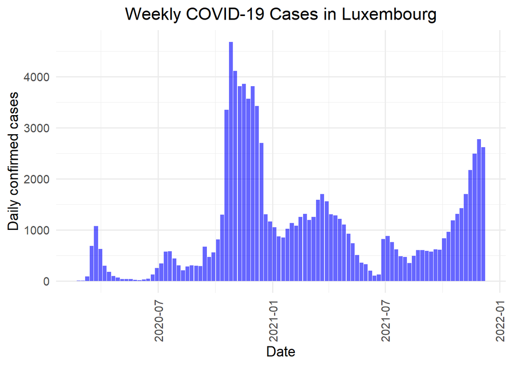

```r
LUX %>% ggplot( aes(date, as.numeric(new_cases))) +
 geom_col(fill = "blue", alpha = 0.6) +
 theme_minimal(base_size = 14) +
  labs(title = "Weekly COVID-19 Cases in Luxembourg", x= "Date", y= "Daily confirmed cases") +
  theme(plot.title = element_text(hjust = 0.5))+
  theme(axis.text.x = element_text(angle = 90, hjust = 1, vjust = .5))
```

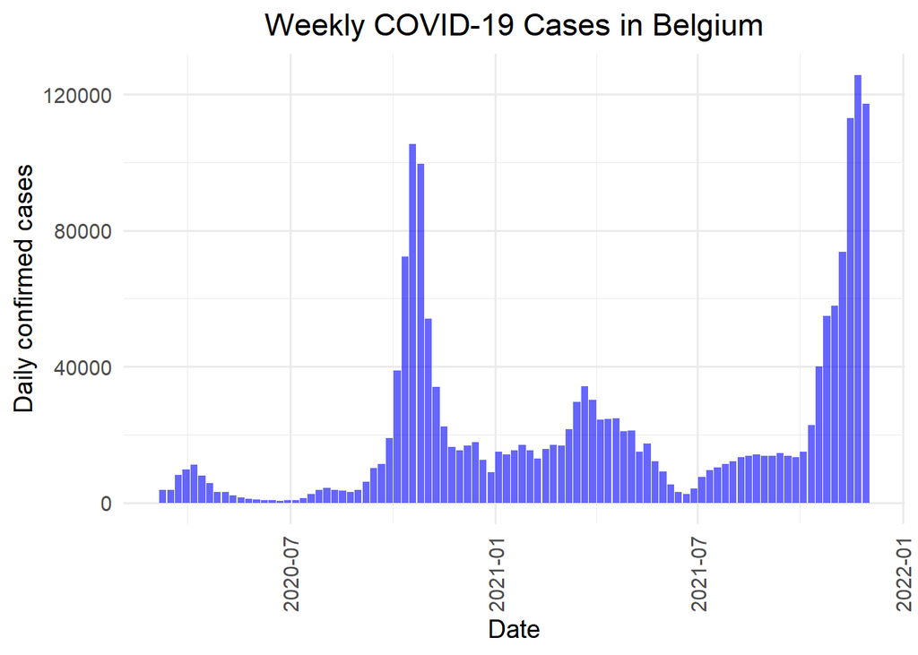

```r
BLG %>% ggplot( aes(date, as.numeric(new_cases))) +
 geom_col(fill = "blue", alpha = 0.6) +
 theme_minimal(base_size = 14) +
  labs(title = "Weekly COVID-19 Cases in Belgium", x= "Date", y= "Daily confirmed cases") +
  theme(plot.title = element_text(hjust = 0.5))+
  theme(axis.text.x = element_text(angle = 90, hjust = 1, vjust = .5))
```

# Weekly confirmed new cases per capita calculation (cpc)

```r
lux_population = 626108
blg_population = 11522440

LUX$cpc <- 10000*LUX$new_cases/lux_population
BLG$cpc <- 10000*BLG$new_cases/blg_population
```

# start and end dates for the calculations

```r
start_date = as.Date("2020-7-1")
end_date = as.Date("2021-12-15")
```